# mald hafa

```python
dict_of_model={'RandomForest':RandomForest,
              'AdaBoost':AdaBoost,
               'GBC':GBC,
               'XGB':XGB,
              'SVM':SVM,
             'LRG':LRG,
               'SGD':SGD,
              'KNN':KNN,
              'GNB':GNB,
              'BNB':BNB,
              'MNB':MNB} #,
            #  'CNB':CNB}
```

```
RandomForest
[[ 61  10]
 [  7 132]]
              precision    recall  f1-score   support

           0       0.90      0.86      0.88        71
           1       0.93      0.95      0.94       139

    accuracy                           0.92       210
   macro avg       0.91      0.90      0.91       210
weighted avg       0.92      0.92      0.92       210
```

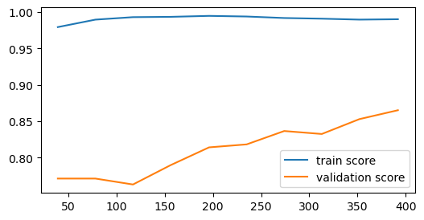

```
AdaBoost
[[ 41  30]
 [ 14 125]]
              precision    recall  f1-score   support

           0       0.75      0.58      0.65        71
           1       0.81      0.90      0.85       139

    accuracy                           0.79       210
   macro avg       0.78      0.74      0.75       210
weighted avg       0.79      0.79      0.78       210
```

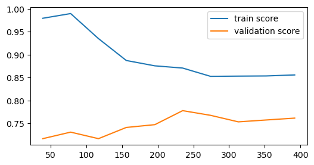

```
GBC
[[ 52  19]
 [ 10 129]]
              precision    recall  f1-score   support

           0       0.84      0.73      0.78        71
           1       0.87      0.93      0.90       139

    accuracy                           0.86       210
   macro avg       0.86      0.83      0.84       210
weighted avg       0.86      0.86      0.86       210
```

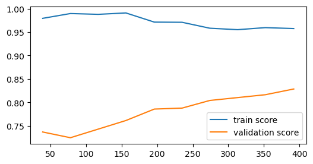

```
XGB
[[ 59  12]
 [ 12 127]]
              precision    recall  f1-score   support

           0       0.83      0.83      0.83        71
           1       0.91      0.91      0.91       139

    accuracy                           0.89       210
   macro avg       0.87      0.87      0.87       210
weighted avg       0.89      0.89      0.89       210
```

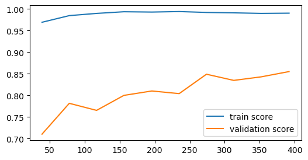

```
SVM
[[ 43  28]
 [ 13 126]]
              precision    recall  f1-score   support

           0       0.77      0.61      0.68        71
           1       0.82      0.91      0.86       139

    accuracy                           0.80       210
   macro avg       0.79      0.76      0.77       210
weighted avg       0.80      0.80      0.80       210
```

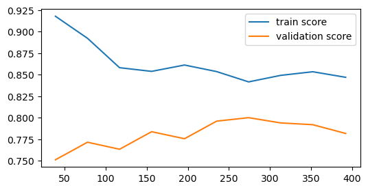

```
LRG
[[ 41  30]
 [ 23 116]]
              precision    recall  f1-score   support

           0       0.64      0.58      0.61        71
           1       0.79      0.83      0.81       139

    accuracy                           0.75       210
   macro avg       0.72      0.71      0.71       210
weighted avg       0.74      0.75      0.74       210
```

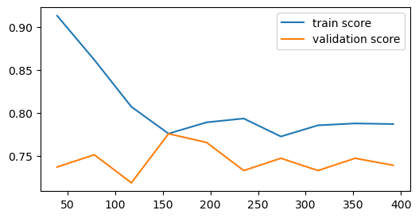

```
SGD
[[55 16]
 [54 85]]
              precision    recall  f1-score   support

           0       0.50      0.77      0.61        71
           1       0.84      0.61      0.71       139

    accuracy                           0.67       210
   macro avg       0.67      0.69      0.66       210
weighted avg       0.73      0.67      0.68       210
```

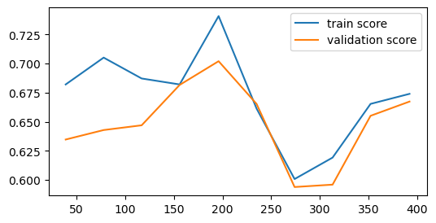

```
KNN
[[ 46  25]
 [ 23 116]]
              precision    recall  f1-score   support

           0       0.67      0.65      0.66        71
           1       0.82      0.83      0.83       139

    accuracy                           0.77       210
   macro avg       0.74      0.74      0.74       210
weighted avg       0.77      0.77      0.77       210
```

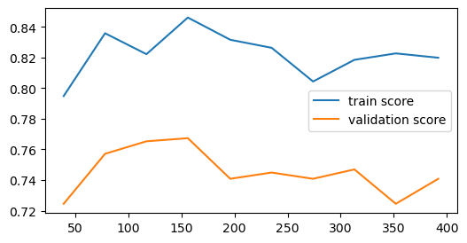

```
GNB
[[ 50  21]
 [ 36 103]]
              precision    recall  f1-score   support

           0       0.58      0.70      0.64        71
           1       0.83      0.74      0.78       139

    accuracy                           0.73       210
   macro avg       0.71      0.72      0.71       210
weighted avg       0.75      0.73      0.73       210
```

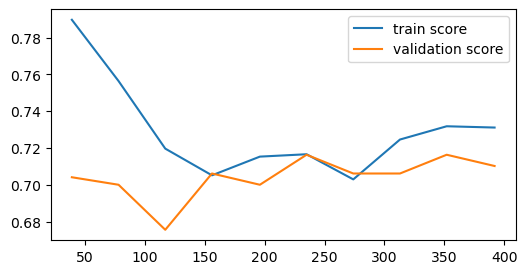

```
BNB
[[47 24]
 [41 98]]
              precision    recall  f1-score   support

           0       0.53      0.66      0.59        71
           1       0.80      0.71      0.75       139

    accuracy                           0.69       210
   macro avg       0.67      0.68      0.67       210
weighted avg       0.71      0.69      0.70       210
```

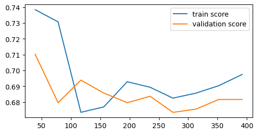

```
MNB
[[ 40  31]
 [ 28 111]]
              precision    recall  f1-score   support

           0       0.59      0.56      0.58        71
           1       0.78      0.80      0.79       139

    accuracy                           0.72       210
   macro avg       0.68      0.68      0.68       210
weighted avg       0.72      0.72      0.72       210
```

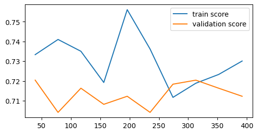

```python
warnings.filterwarnings('ignore')
for name, model in dict_of_model.items():
    print(name)
    evaluation(model)
```

Nesorina ireo variable jugées tsy importantes dia variables 19 sisa hatreto anaovana entrainement Mbola voatazona hatreto ireo variables liées amn'ny examen blanc izay atao any am faran'ny taona

```python
df2=df[['col_statut','sujet_degre','imp1','imp2','imp3','imp5','imp6','imp10','col_milieu','nbre_elev_SDC','mere_niv_ac','Ran_TbB','elev_presco','etab_prim_stat','cour_supl','acces_TICE','mean_blanc','note_math','Delinquance','réussite']]
#df2=df[['imp3','imp5','imp6','imp10','nbre_elev_SDC','mere_niv_ac','Ran_TbB','etab_prim_stat','cour_supl','acces_TICE','mean_blanc','note_math','Delinquance','réussite']]
df2.head()
```

|  | col_statut | sujet_degre | imp1 | imp2 | imp3 | imp5 | imp6 | imp10 | col_milieu | nbre_elev_SDC | mere_niv_ac | Ran_TbB | elev_presco | etab_prim_stat | cour_supl | acces_TICE | mean_blanc | note_math | Delinquance | réussite |
| --- | --- | --- | --- | --- | --- | --- | --- | --- | --- | --- | --- | --- | --- | --- | --- | --- | --- | --- | --- | --- |
| 0 | 1 | 1.0 | 1 | 1 | 1 | 1 | 1.0 | 1 | 0 | 40 | 1.0 | 1 | 1 | 1 | 1 | 1 | 11.75 | 13.5 | 1.0 | 1 |
| 1 | 1 | 1.0 | 1 | 0 | 1 | 1 | 0.0 | 1 | 0 | 70 | 2.0 | 1 | 0 | 1 | 0 | 0 | 12.00 | 14.0 | 0.0 | 1 |
| 2 | 1 | 1.0 | 1 | 1 | 1 | 1 | 1.0 | 1 | 1 | 50 | 1.0 | 2 | 1 | 1 | 1 | 1 | 10.00 | 15.0 | 0.0 | 1 |
| 3 | 0 | 0.0 | 1 | 1 | 0 | 1 | 0.0 | 1 | 1 | 39 | 1.0 | 2 | 1 | 0 | 1 | 0 | 13.00 | 12.0 | 0.0 | 1 |
| 4 | 1 | 1.0 | 1 | 0 | 0 | 0 | 0.0 | 1 | 0 | 43 | 1.0 | 3 | 1 | 1 | 1 | 0 | 8.50 | 9.0 | 0.0 | 0 |

```python
#bins=pd.IntervalIndex.from_tuples([(0,50),(50,100),(100,150)])
#df2['nbre_elev_SDC']=pd.cut(np.array(df2['nbre_elev_SDC']),include_lowest=True, bins=bins,labels=range(3))
#df2['nbre_elev_SDC']
```

```python
#bins1=pd.IntervalIndex.from_tuples([(0,8),(8,13),(13,21)])
#df2['mean_blanc']=pd.cut(np.array(df2['mean_blanc']),include_lowest=True, bins=bins1,labels=range(3))
#df2['mean_blanc']
```

```python
#bins2=pd.IntervalIndex.from_tuples([(0,8),(8,13),(13,21)])
#df2['note_math']=pd.cut(np.array(df2['note_math']),include_lowest=True, bins=bins2,labels=range(2))
#df2['note_math']
```

```python
#df2['note_math']=df2['note_math'].cat.codes
#df2['mean_blanc']=df2['mean_blanc'].cat.codes
#df2['nbre_elev_SDC']=df2['nbre_elev_SDC'].cat.codes
```

Crééna eto ny base de données d'entrainement sy ny base de données de test à partir anlay df2 misy variables reduites à 19. 30% données tests de 70% données d'entrainement

```python
trainset,testset=train_test_split(df2, random_state=0,test_size=0.3)
```

```python
def imputation(df):
    return df.dropna(axis=0)
```

```python
def preprocessing(df):
    df=imputation(df)
    X=df.drop(['réussite'],axis=1)
    y=df['réussite']
    print(y.value_counts())
    return X,y
```

```python
X_train, y_train=preprocessing(trainset)
```

```
réussite
1    315
0    175
Name: count, dtype: int64
```

```python
X_test,y_test=preprocessing(testset)
```

```
réussite
1    139
0     71
Name: count, dtype: int64
```

```python
preprocessor=make_pipeline(SelectKBest(chi2, k=10)) # Jerena izay 'k' variables importantes dia iny no anaovana ny entrainement
```

```python
RandomForest=make_pipeline(preprocessor, RandomForestClassifier(random_state=0))
AdaBoost=make_pipeline(preprocessor, AdaBoostClassifier(random_state=0))
GBC=make_pipeline(preprocessor, GradientBoostingClassifier(random_state=0))
XGB=make_pipeline(preprocessor, XGBClassifier())
SVM=make_pipeline(preprocessor, StandardScaler(), SVC(random_state=0))
KNN=make_pipeline(preprocessor, StandardScaler(), KNeighborsClassifier())
GNB=make_pipeline(preprocessor, StandardScaler(), GaussianNB())
MNB=make_pipeline(preprocessor,MultinomialNB())
LRG=make_pipeline(preprocessor, LogisticRegression())
SGD=make_pipeline(preprocessor, StandardScaler(), SGDClassifier())
BNB=make_pipeline(preprocessor, BernoulliNB())
```

```python
list_of_models=[RandomForest, AdaBoost, GBC, XGB, SVM, KNN, GNB,LRG,SGD, BNB,MNB]
```

```python
dict_of_model={'RandomForest':RandomForest,
              'AdaBoost':AdaBoost,
               'GBC':GBC,
               'XGB':XGB,
              'SVM':SVM,
             'LRG':LRG,
               'SGD':SGD,
              'KNN':KNN,
              'GNB':GNB,
              'BNB':BNB,
              'MNB':MNB}
```

```
RandomForest
[[ 61  10]
 [  5 134]]
              precision    recall  f1-score   support

           0       0.92      0.86      0.89        71
           1       0.93      0.96      0.95       139

    accuracy                           0.93       210
   macro avg       0.93      0.91      0.92       210
weighted avg       0.93      0.93      0.93       210
```

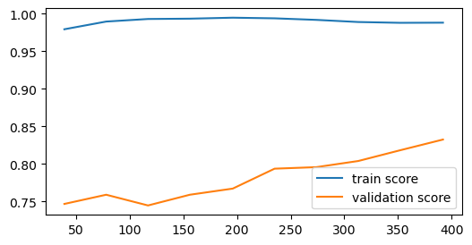

```
AdaBoost
[[ 33  38]
 [ 15 124]]
              precision    recall  f1-score   support

           0       0.69      0.46      0.55        71
           1       0.77      0.89      0.82       139

    accuracy                           0.75       210
   macro avg       0.73      0.68      0.69       210
weighted avg       0.74      0.75      0.73       210
```

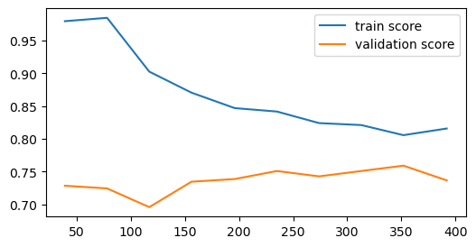

```
GBC
[[ 49  22]
 [ 10 129]]
              precision    recall  f1-score   support

           0       0.83      0.69      0.75        71
           1       0.85      0.93      0.89       139

    accuracy                           0.85       210
   macro avg       0.84      0.81      0.82       210
weighted avg       0.85      0.85      0.84       210
```

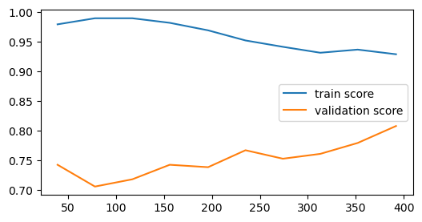

```
XGB
[[ 60  11]
 [  6 133]]
              precision    recall  f1-score   support

           0       0.91      0.85      0.88        71
           1       0.92      0.96      0.94       139

    accuracy                           0.92       210
   macro avg       0.92      0.90      0.91       210
weighted avg       0.92      0.92      0.92       210
```

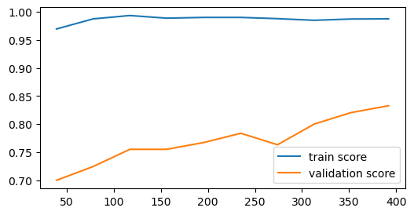

```
SVM
[[ 39  32]
 [ 14 125]]
              precision    recall  f1-score   support

           0       0.74      0.55      0.63        71
           1       0.80      0.90      0.84       139

    accuracy                           0.78       210
   macro avg       0.77      0.72      0.74       210
weighted avg       0.78      0.78      0.77       210
```

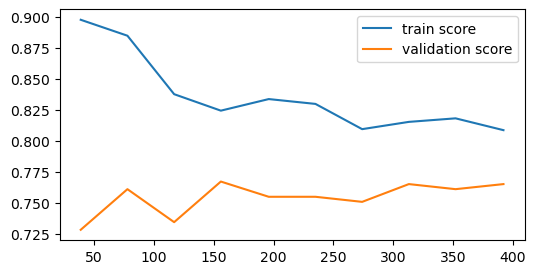

```
LRG
[[ 33  38]
 [ 16 123]]
              precision    recall  f1-score   support

           0       0.67      0.46      0.55        71
           1       0.76      0.88      0.82       139

    accuracy                           0.74       210
   macro avg       0.72      0.67      0.69       210
weighted avg       0.73      0.74      0.73       210
```

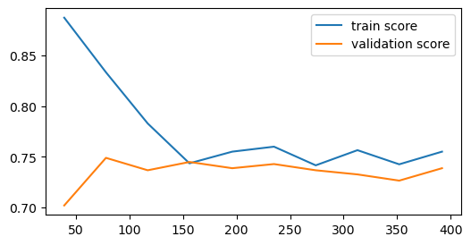

```
SGD
[[51 20]
 [55 84]]
              precision    recall  f1-score   support

           0       0.48      0.72      0.58        71
           1       0.81      0.60      0.69       139

    accuracy                           0.64       210
   macro avg       0.64      0.66      0.63       210
weighted avg       0.70      0.64      0.65       210
```

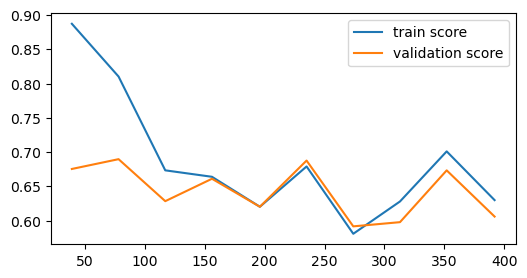

```
KNN
[[ 39  32]
 [ 22 117]]
              precision    recall  f1-score   support

           0       0.64      0.55      0.59        71
           1       0.79      0.84      0.81       139

    accuracy                           0.74       210
   macro avg       0.71      0.70      0.70       210
weighted avg       0.74      0.74      0.74       210
```

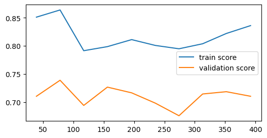

```
GNB
[[ 48  23]
 [ 39 100]]
              precision    recall  f1-score   support

           0       0.55      0.68      0.61        71
           1       0.81      0.72      0.76       139

    accuracy                           0.70       210
   macro avg       0.68      0.70      0.69       210
weighted avg       0.72      0.70      0.71       210
```

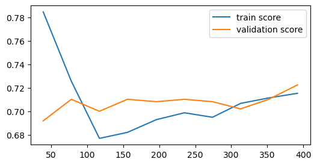

```
BNB
[[ 49  22]
 [ 38 101]]
              precision    recall  f1-score   support

           0       0.56      0.69      0.62        71
           1       0.82      0.73      0.77       139

    accuracy                           0.71       210
   macro avg       0.69      0.71      0.70       210
weighted avg       0.73      0.71      0.72       210
```

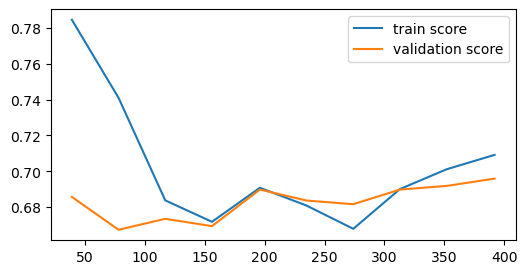

```
MNB
[[ 36  35]
 [ 35 104]]
              precision    recall  f1-score   support

           0       0.51      0.51      0.51        71
           1       0.75      0.75      0.75       139

    accuracy                           0.67       210
   macro avg       0.63      0.63      0.63       210
weighted avg       0.67      0.67      0.67       210
```

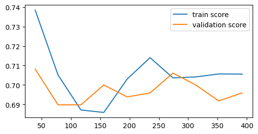

```python
warnings.filterwarnings('ignore')
for name, model in dict_of_model.items():
    print(name)
    evaluation(model)
```

Rehefa noraisina oe k='all', zan hoe ilay variables explicatives 19 nampiasaina daholo amin'ny entrainement dia ny RandomForest sy ny XGBoost no modèle manome performance ambony indrindra ary samy mahatratra 90% avokoa ny accuracy an'izy roa.\ Raha nahena kosa ny 'k' dia toy izao ny fiovana hita : \ k : 15 10 précision RF : 90% 93% Précision XGB : 93% 92%

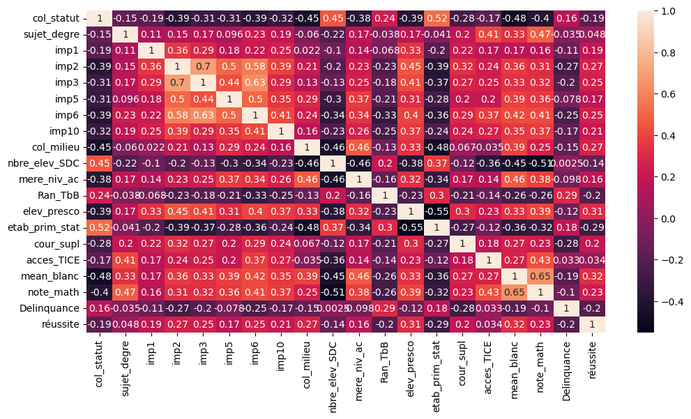

```python
plt.figure(figsize=(12,6))
sns.heatmap(df2.corr(),annot=True)
plt.show()
```

```python
for col in df2.columns:
    df_count=pd.crosstab(df2['réussite'],df2[col])
    Khi2_obs, p_value, ddl, effectif_theorique=chi2_contingency(df_count)
    print('p-value (Réusiite',col,')',p_value)
```

```
p-value (Réusiite col_statut ) 1.337765042269771e-06
p-value (Réusiite sujet_degre ) 0.23602061539564198
p-value (Réusiite imp1 ) 1.7388285681600023e-06
p-value (Réusiite imp2 ) 1.8779962098240615e-12
p-value (Réusiite imp3 ) 3.433350951198398e-11
p-value (Réusiite imp5 ) 8.705215467950725e-06
p-value (Réusiite imp6 ) 2.7435229036120134e-11
p-value (Réusiite imp10 ) 8.14028540386343e-08
p-value (Réusiite col_milieu ) 2.157891887126665e-12
p-value (Réusiite nbre_elev_SDC ) 6.542360737352804e-19
p-value (Réusiite mere_niv_ac ) 0.0001698859447505909
p-value (Réusiite Ran_TbB ) 3.7565355799513654e-07
p-value (Réusiite elev_presco ) 5.001463825180141e-15
p-value (Réusiite etab_prim_stat ) 6.035994627781971e-14
p-value (Réusiite cour_supl ) 3.736192436447435e-07
p-value (Réusiite acces_TICE ) 0.4161557669189254
p-value (Réusiite mean_blanc ) 1.1148275049876671e-18
p-value (Réusiite note_math ) 3.042366068623449e-09
p-value (Réusiite Delinquance ) 1.322859762003648e-07
p-value (Réusiite réussite ) 2.6808825051488584e-153
```

```python
for col in df2.columns:
    for col2 in df2.columns:
        df_count=pd.crosstab(df2[col2],df2[col])
        #Khi2_obs, p_value, ddl, effectif_theorique=chi2_contingency(df_count)
        chi2_contingency(df_count)
        print('p-value(',col2,',',col,')',chi2_contingency(df_count)[1])
```

```
p-value( col_statut , col_statut ) 2.352131690677079e-153
p-value( sujet_degre , col_statut ) 6.197385451927591e-05
p-value( imp1 , col_statut ) 6.228370209732632e-07
p-value( imp2 , col_statut ) 1.400521791228176e-24
p-value( imp3 , col_statut ) 1.910503283973058e-16
p-value( imp5 , col_statut ) 3.46406683291835e-16
p-value( imp6 , col_statut ) 3.87622247963307e-25
p-value( imp10 , col_statut ) 4.794603960219753e-17
p-value( col_milieu , col_statut ) 2.3516408236734747e-32
p-value( nbre_elev_SDC , col_statut ) 4.0724443193429e-38
p-value( mere_niv_ac , col_statut ) 3.6627079218544366e-23
p-value( Ran_TbB , col_statut ) 1.5677387934344525e-10
p-value( elev_presco , col_statut ) 2.2317091739569025e-25
p-value( etab_prim_stat , col_statut ) 2.1671786005502203e-42
p-value( cour_supl , col_statut ) 5.140819747891726e-13
p-value( acces_TICE , col_statut ) 1.0338240741702994e-05
p-value( mean_blanc , col_statut ) 1.394345962734842e-32
p-value( note_math , col_statut ) 3.234154901005358e-20
p-value( Delinquance , col_statut ) 3.9726449571674984e-05
p-value( réussite , col_statut ) 1.337765042269771e-06
p-value( col_statut , sujet_degre ) 6.197385451927591e-05
p-value( sujet_degre , sujet_degre ) 2.251926212346346e-153
p-value( imp1 , sujet_degre ) 0.004883246411304315
p-value( imp2 , sujet_degre ) 0.0001275448542989801
p-value( imp3 , sujet_degre ) 1.0932226845051118e-05
p-value( imp5 , sujet_degre ) 0.01413577216699439
p-value( imp6 , sujet_degre ) 2.1378482475513873e-09
p-value( imp10 , sujet_degre ) 1.4283708479380392e-06
p-value( col_milieu , sujet_degre ) 0.13143114928368868
p-value( nbre_elev_SDC , sujet_degre ) 1.522075669318836e-13
p-value( mere_niv_ac , sujet_degre ) 1.8172775741257756e-06
p-value( Ran_TbB , sujet_degre ) 0.1762207010857017
p-value( elev_presco , sujet_degre ) 4.069237060363447e-05
p-value( etab_prim_stat , sujet_degre ) 0.3094995578875888
p-value( cour_supl , sujet_degre ) 3.0731122279397925e-07
p-value( acces_TICE , sujet_degre ) 4.489618543886318e-27
p-value( mean_blanc , sujet_degre ) 1.8713337299492882e-13
p-value( note_math , sujet_degre ) 1.6677879859251092e-30
p-value( Delinquance , sujet_degre ) 0.4072568759342916
p-value( réussite , sujet_degre ) 0.23602061539564198
```

[output cut: 345 more lines]

```
p-value( imp5 , réussite ) 8.705215467950736e-06
p-value( imp6 , réussite ) 2.7435229036120134e-11
p-value( imp10 , réussite ) 8.14028540386343e-08
p-value( col_milieu , réussite ) 2.157891887126665e-12
p-value( nbre_elev_SDC , réussite ) 6.542360737352804e-19
p-value( mere_niv_ac , réussite ) 0.0001698859447505909
p-value( Ran_TbB , réussite ) 3.7565355799513654e-07
p-value( elev_presco , réussite ) 5.001463825180141e-15
p-value( etab_prim_stat , réussite ) 6.035994627781971e-14
p-value( cour_supl , réussite ) 3.736192436447444e-07
p-value( acces_TICE , réussite ) 0.4161557669189254
p-value( mean_blanc , réussite ) 1.1148275049876671e-18
p-value( note_math , réussite ) 3.0423660686234707e-09
p-value( Delinquance , réussite ) 1.322859762003648e-07
p-value( réussite , réussite ) 2.6808825051488584e-153
```

```python
rf_model=RandomForestClassifier(criterion='entropy', max_features='log2', warm_start=True)
```

```python
rf_model.fit(X_train,y_train)
```

```
RandomForestClassifier(criterion='entropy', max_features='log2',
                       warm_start=True)
```

```python
ypred=rf_model.predict(X_test)

print (confusion_matrix(y_test,ypred))
print (classification_report(y_test,ypred))
```

```
[[ 58  13]
 [  8 131]]
              precision    recall  f1-score   support

           0       0.88      0.82      0.85        71
           1       0.91      0.94      0.93       139

    accuracy                           0.90       210
   macro avg       0.89      0.88      0.89       210
weighted avg       0.90      0.90      0.90       210
```

```python
impVarFirst={"Variable":df2.columns[:-1],"Importance":rf_model.feature_importances_}
print(pd.DataFrame(impVarFirst).sort_values(by="Importance",ascending=False))
```

```
          Variable  Importance
16      mean_blanc    0.216310
9    nbre_elev_SDC    0.143126
17       note_math    0.121055
11         Ran_TbB    0.066896
10     mere_niv_ac    0.057248
12     elev_presco    0.042426
8       col_milieu    0.036990
13  etab_prim_stat    0.034335
6             imp6    0.032995
18     Delinquance    0.030298
1      sujet_degre    0.029805
4             imp3    0.029160
3             imp2    0.027758
5             imp5    0.027653
0       col_statut    0.024057
15      acces_TICE    0.023646
7            imp10    0.021618
14       cour_supl    0.019234
2             imp1    0.015389
```

Nohezahana nofantarina ary ireo variables 15 importantes ka nesorina izay ts anatiny. ankoatr'ireo dia nesorina ihany koa ny variable note_math sy ny moyenne am BEPC blanc satria lasa sakana amn fampiasana ny modèle mialoha. (df3 zan ny base de données miala anlay )

```python
#df3=df[['sujet_degre','imp1','imp3','imp5','imp6','imp10','col_milieu','nbre_elev_SDC','mere_niv_ac','Ran_TbB','elev_presco','etab_prim_stat','cour_supl','acces_TICE','Delinquance','réussite']]
#df3=df[['imp2','imp3','imp5','imp6','imp10','nbre_elev_SDC','mere_niv_ac','Ran_TbB','etab_prim_stat','cour_supl','Delinquance','elev_presco','col_milieu','acces_TICE','col_statut','réussite']]
df3=df[['imp2','imp3','imp5','imp6','imp10','nbre_elev_SDC','mere_niv_ac','Ran_TbB','etab_prim_stat','cour_supl','elev_presco','acces_TICE','col_statut','réussite']]
df3.head()
```

|  | imp2 | imp3 | imp5 | imp6 | imp10 | nbre_elev_SDC | mere_niv_ac | Ran_TbB | etab_prim_stat | cour_supl | elev_presco | acces_TICE | col_statut | réussite |
| --- | --- | --- | --- | --- | --- | --- | --- | --- | --- | --- | --- | --- | --- | --- |
| 0 | 1 | 1 | 1 | 1.0 | 1 | 40 | 1.0 | 1 | 1 | 1 | 1 | 1 | 1 | 1 |
| 1 | 0 | 1 | 1 | 0.0 | 1 | 70 | 2.0 | 1 | 1 | 0 | 0 | 0 | 1 | 1 |
| 2 | 1 | 1 | 1 | 1.0 | 1 | 50 | 1.0 | 2 | 1 | 1 | 1 | 1 | 1 | 1 |
| 3 | 1 | 0 | 1 | 0.0 | 1 | 39 | 1.0 | 2 | 0 | 1 | 1 | 0 | 0 | 1 |
| 4 | 0 | 0 | 0 | 0.0 | 1 | 43 | 1.0 | 3 | 1 | 1 | 1 | 0 | 1 | 0 |

```python
trainset3,testset3=train_test_split(df3, random_state=0,test_size=0.3)
```

```python
X_train3, y_train3=preprocessing(trainset3)
```

```
réussite
1    315
0    175
Name: count, dtype: int64
```

```python
X_test3,y_test3=preprocessing(testset3)
```

```
réussite
1    139
0     71
Name: count, dtype: int64
```

```python
preprocessor=make_pipeline(SelectKBest(f_classif, k='all')) # Jerena izay 'k' variables importantes dia iny no anaovana ny entrainement
```

```python
RandomForest=make_pipeline(preprocessor, RandomForestClassifier(random_state=0))
AdaBoost=make_pipeline(preprocessor, AdaBoostClassifier(random_state=0))
GBC=make_pipeline(preprocessor, GradientBoostingClassifier(random_state=0))
XGB=make_pipeline(preprocessor, XGBClassifier())
SVM=make_pipeline(preprocessor, StandardScaler(), SVC(random_state=0))
KNN=make_pipeline(preprocessor, StandardScaler(), KNeighborsClassifier())
GNB=make_pipeline(preprocessor, StandardScaler(), GaussianNB())
MNB=make_pipeline(preprocessor,MultinomialNB())
LRG=make_pipeline(preprocessor, LogisticRegression())
SGD=make_pipeline(preprocessor, StandardScaler(), SGDClassifier())
BNB=make_pipeline(preprocessor, BernoulliNB())
```

```python
list_of_models=[RandomForest, AdaBoost, GBC, XGB, SVM, KNN, GNB,LRG,SGD, BNB,MNB]
```

```python
dict_of_model={'RandomForest':RandomForest,
              'AdaBoost':AdaBoost,
               'GBC':GBC,
               'XGB':XGB,
              'SVM':SVM,
             'LRG':LRG,
               'SGD':SGD,
              'KNN':KNN,
              'GNB':GNB,
              'BNB':BNB,
              'MNB':MNB}
```

```
RandomForest
[[ 58  13]
 [  7 132]]
              precision    recall  f1-score   support

           0       0.89      0.82      0.85        71
           1       0.91      0.95      0.93       139

    accuracy                           0.90       210
   macro avg       0.90      0.88      0.89       210
weighted avg       0.90      0.90      0.90       210
```

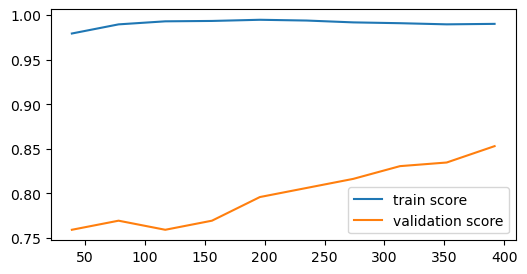

```
AdaBoost
[[ 34  37]
 [ 18 121]]
              precision    recall  f1-score   support

           0       0.65      0.48      0.55        71
           1       0.77      0.87      0.81       139

    accuracy                           0.74       210
   macro avg       0.71      0.67      0.68       210
weighted avg       0.73      0.74      0.73       210
```

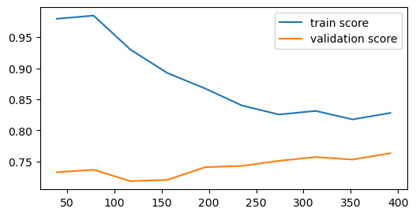

```
GBC
[[ 53  18]
 [  6 133]]
              precision    recall  f1-score   support

           0       0.90      0.75      0.82        71
           1       0.88      0.96      0.92       139

    accuracy                           0.89       210
   macro avg       0.89      0.85      0.87       210
weighted avg       0.89      0.89      0.88       210
```

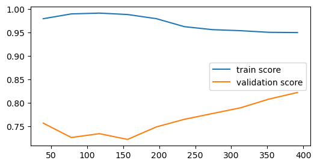

```
XGB
[[ 58  13]
 [  7 132]]
              precision    recall  f1-score   support

           0       0.89      0.82      0.85        71
           1       0.91      0.95      0.93       139

    accuracy                           0.90       210
   macro avg       0.90      0.88      0.89       210
weighted avg       0.90      0.90      0.90       210
```

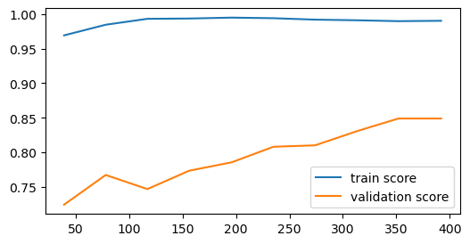

```
SVM
[[ 39  32]
 [ 12 127]]
              precision    recall  f1-score   support

           0       0.76      0.55      0.64        71
           1       0.80      0.91      0.85       139

    accuracy                           0.79       210
   macro avg       0.78      0.73      0.75       210
weighted avg       0.79      0.79      0.78       210
```

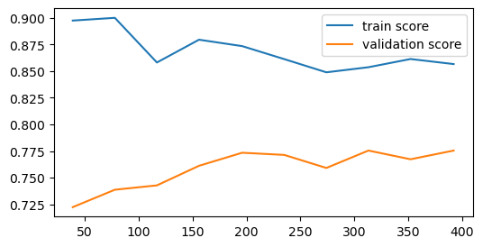

```
LRG
[[ 40  31]
 [ 21 118]]
              precision    recall  f1-score   support

           0       0.66      0.56      0.61        71
           1       0.79      0.85      0.82       139

    accuracy                           0.75       210
   macro avg       0.72      0.71      0.71       210
weighted avg       0.75      0.75      0.75       210
```

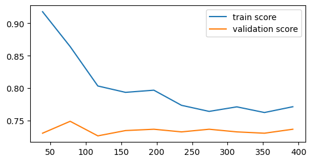

```
SGD
[[ 37  34]
 [ 33 106]]
              precision    recall  f1-score   support

           0       0.53      0.52      0.52        71
           1       0.76      0.76      0.76       139

    accuracy                           0.68       210
   macro avg       0.64      0.64      0.64       210
weighted avg       0.68      0.68      0.68       210
```

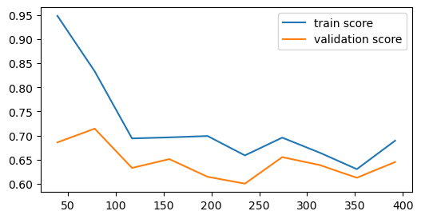

```
KNN
[[ 42  29]
 [ 23 116]]
              precision    recall  f1-score   support

           0       0.65      0.59      0.62        71
           1       0.80      0.83      0.82       139

    accuracy                           0.75       210
   macro avg       0.72      0.71      0.72       210
weighted avg       0.75      0.75      0.75       210
```

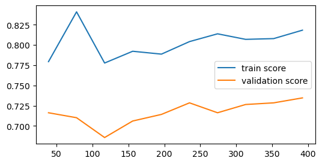

```
GNB
[[48 23]
 [45 94]]
              precision    recall  f1-score   support

           0       0.52      0.68      0.59        71
           1       0.80      0.68      0.73       139

    accuracy                           0.68       210
   macro avg       0.66      0.68      0.66       210
weighted avg       0.71      0.68      0.68       210
```

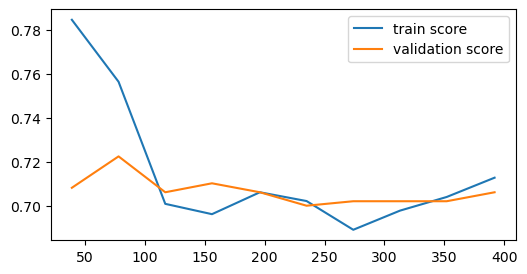

```
BNB
[[47 24]
 [40 99]]
              precision    recall  f1-score   support

           0       0.54      0.66      0.59        71
           1       0.80      0.71      0.76       139

    accuracy                           0.70       210
   macro avg       0.67      0.69      0.68       210
weighted avg       0.72      0.70      0.70       210
```

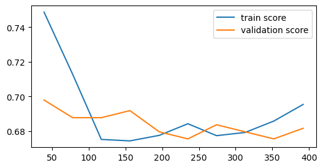

```
MNB
[[ 37  34]
 [ 36 103]]
              precision    recall  f1-score   support

           0       0.51      0.52      0.51        71
           1       0.75      0.74      0.75       139

    accuracy                           0.67       210
   macro avg       0.63      0.63      0.63       210
weighted avg       0.67      0.67      0.67       210
```

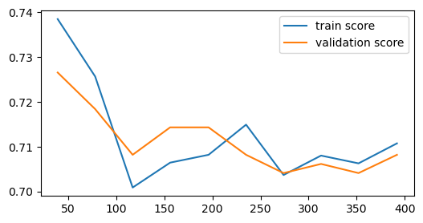

```python
for name, model in dict_of_model.items():
    print(name)
    evaluation(model)
```

```python
for col in df3.columns:
    for col2 in df3.columns:
        df_count=pd.crosstab(df3[col2],df3[col])
        #Khi2_obs, p_value, ddl, effectif_theorique=chi2_contingency(df_count)
        chi2_contingency(df_count)
        print('p-value(',col2,',',col,')',chi2_contingency(df_count)[1])
```

```
p-value( imp2 , imp2 ) 2.2380928074744849e-153
p-value( imp3 , imp2 ) 3.5330628708282866e-75
p-value( imp5 , imp2 ) 3.2402096767178067e-39
p-value( imp6 , imp2 ) 6.810312910559762e-52
p-value( imp10 , imp2 ) 2.5936959766289693e-24
p-value( nbre_elev_SDC , imp2 ) 4.077976731418337e-17
p-value( mere_niv_ac , imp2 ) 8.41345392376849e-10
p-value( Ran_TbB , imp2 ) 1.332374675863553e-08
p-value( etab_prim_stat , imp2 ) 8.403979574101017e-25
p-value( cour_supl , imp2 ) 6.834924627677821e-17
p-value( elev_presco , imp2 ) 4.6665617322466336e-32
p-value( acces_TICE , imp2 ) 5.96203302063977e-10
p-value( col_statut , imp2 ) 1.400521791228176e-24
p-value( réussite , imp2 ) 1.8779962098240615e-12
p-value( imp2 , imp3 ) 3.5330628708282866e-75
p-value( imp3 , imp3 ) 2.2095225587670284e-153
p-value( imp5 , imp3 ) 2.2227238132607354e-30
p-value( imp6 , imp3 ) 3.5208532895028385e-62
p-value( imp10 , imp3 ) 1.276586827340036e-14
p-value( nbre_elev_SDC , imp3 ) 8.175410033676351e-15
p-value( mere_niv_ac , imp3 ) 1.5138454920141407e-10
p-value( Ran_TbB , imp3 ) 1.759200700657727e-05
p-value( etab_prim_stat , imp3 ) 1.6246303715615993e-22
p-value( cour_supl , imp3 ) 2.554859383820736e-12
p-value( elev_presco , imp3 ) 6.872628174017658e-27
p-value( acces_TICE , imp3 ) 8.000599060231866e-11
p-value( col_statut , imp3 ) 1.9105032839730713e-16
p-value( réussite , imp3 ) 3.433350951198398e-11
p-value( imp2 , imp5 ) 3.2402096767178067e-39
p-value( imp3 , imp5 ) 2.2227238132607354e-30
p-value( imp5 , imp5 ) 2.3113635196560657e-153
p-value( imp6 , imp5 ) 1.956413998863829e-39
p-value( imp10 , imp5 ) 6.695640646005936e-20
p-value( nbre_elev_SDC , imp5 ) 4.5083198862475806e-12
p-value( mere_niv_ac , imp5 ) 7.81428224144468e-21
p-value( Ran_TbB , imp5 ) 1.0564973261488817e-07
p-value( etab_prim_stat , imp5 ) 5.708203556693726e-13
p-value( cour_supl , imp5 ) 2.484383974485522e-07
p-value( elev_presco , imp5 ) 3.2793563402749933e-15
p-value( acces_TICE , imp5 ) 1.272476764932886e-07
```

[output cut: 141 more lines]

```
p-value( réussite , col_statut ) 1.337765042269771e-06
p-value( imp2 , réussite ) 1.877996209824054e-12
p-value( imp3 , réussite ) 3.433350951198398e-11
p-value( imp5 , réussite ) 8.705215467950736e-06
p-value( imp6 , réussite ) 2.7435229036120134e-11
p-value( imp10 , réussite ) 8.14028540386343e-08
p-value( nbre_elev_SDC , réussite ) 6.542360737352804e-19
p-value( mere_niv_ac , réussite ) 0.0001698859447505909
p-value( Ran_TbB , réussite ) 3.7565355799513654e-07
p-value( etab_prim_stat , réussite ) 6.035994627781971e-14
p-value( cour_supl , réussite ) 3.736192436447444e-07
p-value( elev_presco , réussite ) 5.001463825180141e-15
p-value( acces_TICE , réussite ) 0.4161557669189254
p-value( col_statut , réussite ) 1.337765042269771e-06
p-value( réussite , réussite ) 2.6808825051488584e-153
```

```python
rf_model3=RandomForestClassifier(criterion='log_loss', max_features='sqrt', warm_start=True, class_weight='balanced')
```

```python
rf_model3.fit(X_train3,y_train3)
```

```
RandomForestClassifier(class_weight='balanced', criterion='log_loss',
                       warm_start=True)
```

```python
y_pred3=rf_model3.predict(X_test3)

print (confusion_matrix(y_test3,y_pred3))
print (classification_report(y_test3,y_pred3))
```

```
[[ 59  12]
 [ 23 116]]
              precision    recall  f1-score   support

           0       0.72      0.83      0.77        71
           1       0.91      0.83      0.87       139

    accuracy                           0.83       210
   macro avg       0.81      0.83      0.82       210
weighted avg       0.84      0.83      0.84       210
```

```python
impVarFirst={"Variable":df3.columns[:-1],"Importance":rf_model3.feature_importances_}
print(pd.DataFrame(impVarFirst).sort_values(by="Importance",ascending=False))
```

```
          Variable  Importance
5    nbre_elev_SDC    0.329038
7          Ran_TbB    0.109348
6      mere_niv_ac    0.101178
10     elev_presco    0.055599
2             imp5    0.052394
8   etab_prim_stat    0.049437
4            imp10    0.048892
12      col_statut    0.048280
1             imp3    0.046195
0             imp2    0.042490
11      acces_TICE    0.039668
3             imp6    0.039450
9        cour_supl    0.038031
```

```python
#df4=df[['Age','taille_menage','orphelin','resid_avc_parent','col_statut','imp1','imp2','imp3','imp5','imp6','imp7','imp8','imp10','col_milieu','nbre_elev_SDC',
#        'nbre_elev_TbB','Nbre_absc','rang_fil','pere_niv_ac','mere_niv_ac','Ran_TbB','elev_presco','etab_prim_stat','cour_supl','mean_blanc','note_math','Delinquance','réussite']]
#df2=df[['imp3','imp5','imp6','imp10','nbre_elev_SDC','mere_niv_ac','Ran_TbB','etab_prim_stat','cour_supl','acces_TICE','mean_blanc','note_math','Delinquance','réussite']]
#df4=df[['Age','taille_menage','orphelin','col_statut','imp1','imp3','imp6','imp7','nbre_elev_SDC',
#        'nbre_elev_TbB','pere_niv_ac','mere_niv_ac','elev_presco','etab_prim_stat','cour_supl','note_math','réussite']]
df4=df[['Age','taille_menage','col_statut','orphelin','imp1','imp2','imp3','imp5','imp6','imp7','imp8','imp10','nbre_elev_SDC',
       'nbre_elev_TbB','Nbre_absc','rang_fil','pere_niv_ac','mere_niv_ac','Ran_TbB','elev_presco','etab_prim_stat','cour_supl','mean_blanc','note_math','réussite']]
#df4=df[['Age','taille_menage','col_statut','imp2','imp3','imp5','imp6','imp7','imp8','imp10','nbre_elev_SDC',
#       'nbre_elev_TbB','Nbre_absc','rang_fil','pere_niv_ac','mere_niv_ac','Ran_TbB','elev_presco','etab_prim_stat','cour_supl','réussite']]
df4.head()
```

|  | Age | taille_menage | col_statut | orphelin | imp1 | imp2 | imp3 | imp5 | imp6 | imp7 | imp8 | imp10 | nbre_elev_SDC | nbre_elev_TbB | Nbre_absc | rang_fil | pere_niv_ac | mere_niv_ac | Ran_TbB | elev_presco | etab_prim_stat | cour_supl | mean_blanc | note_math | réussite |
| --- | --- | --- | --- | --- | --- | --- | --- | --- | --- | --- | --- | --- | --- | --- | --- | --- | --- | --- | --- | --- | --- | --- | --- | --- | --- |
| 0 | 18 | 7 | 1 | 0 | 1 | 1 | 1 | 1 | 1.0 | 1 | 1 | 1 | 40 | 1 | 2 | 0.0 | 1.0 | 1.0 | 1 | 1 | 1 | 1 | 11.75 | 13.5 | 1 |
| 1 | 16 | 5 | 1 | 0 | 1 | 0 | 1 | 1 | 0.0 | 1 | 1 | 1 | 70 | 3 | 3 | 2.0 | 2.0 | 2.0 | 1 | 0 | 1 | 0 | 12.00 | 14.0 | 1 |
| 2 | 20 | 8 | 1 | 0 | 1 | 1 | 1 | 1 | 1.0 | 1 | 1 | 1 | 50 | 2 | 3 | 3.0 | 2.0 | 1.0 | 2 | 1 | 1 | 1 | 10.00 | 15.0 | 1 |
| 3 | 16 | 3 | 0 | 1 | 1 | 1 | 0 | 1 | 0.0 | 1 | 1 | 1 | 39 | 2 | 2 | 2.0 | 0.0 | 1.0 | 2 | 1 | 0 | 1 | 13.00 | 12.0 | 1 |
| 4 | 17 | 8 | 1 | 0 | 1 | 0 | 0 | 0 | 0.0 | 1 | 0 | 1 | 43 | 3 | 4 | 3.0 | 1.0 | 1.0 | 3 | 1 | 1 | 1 | 8.50 | 9.0 | 0 |

```python
pval_matrix = pd.DataFrame(np.zeros((df4.shape[1], df4.shape[1])), columns=df4.columns, index=df4.columns)
```

```python
for col in df4.columns:
    for col2 in df4.columns:
        if col!=col2:
            df_count=pd.crosstab(df4[col2],df4[col])
            Khi2_obs, p_value, ddl, effectif_theorique=chi2_contingency(df_count)
            pval_matrix.loc[col, col2] = p_value
        else:
            pval_matrix.loc[col, col2] = np.nan
```

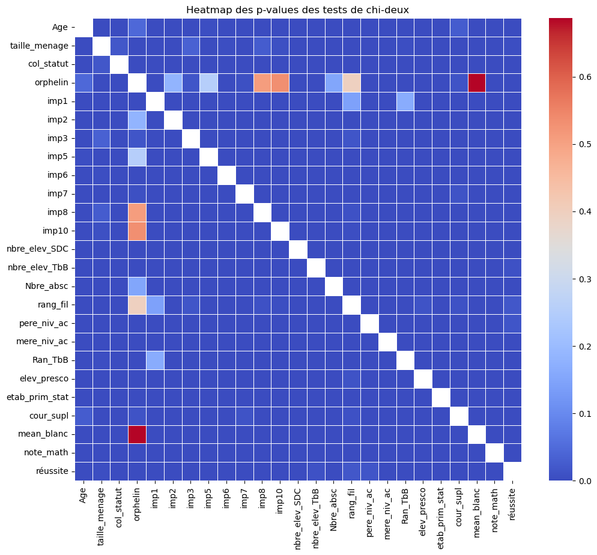

```python
plt.figure(figsize=(12,10))
sns.heatmap(pval_matrix, annot=False, cmap="coolwarm", linewidths=0.5, fmt=".4f", cbar=True)
plt.title("Heatmap des p-values des tests de chi-deux")
plt.savefig('pvaltest5.png')
plt.show()
```

```python
trainset4,testset4=train_test_split(df3, random_state=0,test_size=0.3)
```

```python
X_train4, y_train4=preprocessing(trainset4)
```

```
réussite
1    315
0    175
Name: count, dtype: int64
```

```python
X_test4, y_test4=preprocessing(testset4)
```

```
réussite
1    139
0     71
Name: count, dtype: int64
```

```python
rf_model4=RandomForestClassifier(criterion='entropy', max_features='log2', warm_start=True, random_state=0, bootstrap=True)
```

```python
rf_model4.fit(X_train4,y_train4)
```

```
RandomForestClassifier(criterion='entropy', max_features='log2', random_state=0,
                       warm_start=True)
```

```python
y_pred4=rf_model4.predict(X_test4)

print (confusion_matrix(y_test4,y_pred4))
print (classification_report(y_test4,y_pred4))
```

```
[[ 56  15]
 [ 19 120]]
              precision    recall  f1-score   support

           0       0.75      0.79      0.77        71
           1       0.89      0.86      0.88       139

    accuracy                           0.84       210
   macro avg       0.82      0.83      0.82       210
weighted avg       0.84      0.84      0.84       210
```

```python
from sklearn.model_selection import GridSearchCV
```

```python
RandomForest
```

```
Pipeline(steps=[('pipeline',
                 Pipeline(steps=[('selectkbest', SelectKBest(k='all'))])),
                ('randomforestclassifier',
                 RandomForestClassifier(random_state=0))])
```

```python
hyper_params={'randomforestclassifier__criterion':['entropy', 'gini', 'log_loss'],
              'randomforestclassifier__max_features':['sqrt', 'log2', 'None'],
              'randomforestclassifier__class_weight':['balanced', 'balanced_subsample'],
              #'randomforestclassifier__bootstrap':[True, False],
              #'randomforestclassifier__warm_start':[True, False],
              #'randomforestclassifier__min_impurity_decrease':[0.0,1e-2],
              'pipeline__selectkbest__k':range(10,13)

}
```

```python
grid=GridSearchCV(RandomForest, hyper_params, scoring='accuracy', cv=3)
#grid=GridSearchCV(rf_model3, hyper_params, scoring='precision', cv=3)
grid.fit(X_train3, y_train3)
print(grid.best_params_)
y_pred=grid.predict(X_test3)

print(confusion_matrix(y_test3, y_pred3))
print(classification_report(y_test3, y_pred3))
```

```
{'pipeline__selectkbest__k': 11, 'randomforestclassifier__class_weight': 'balanced', 'randomforestclassifier__criterion': 'entropy', 'randomforestclassifier__max_features': 'sqrt'}
[[ 59  12]
 [ 23 116]]
              precision    recall  f1-score   support

           0       0.72      0.83      0.77        71
           1       0.91      0.83      0.87       139

    accuracy                           0.83       210
   macro avg       0.81      0.83      0.82       210
weighted avg       0.84      0.83      0.84       210
```

```python
best_model=grid.best_estimator_
```

```
[[ 57  14]
 [  8 131]]
              precision    recall  f1-score   support

           0       0.88      0.80      0.84        71
           1       0.90      0.94      0.92       139

    accuracy                           0.90       210
   macro avg       0.89      0.87      0.88       210
weighted avg       0.89      0.90      0.89       210
```

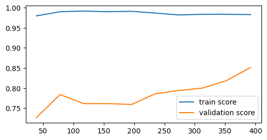

```python
evaluation(best_model)
```

```python
selector = SelectKBest(score_func=f_classif, k=11)
X_new = selector.fit_transform(X_train3, y_train3)

selected_features = X_train3.columns[selector.get_support()]
print(selected_features)
```

```
Index(['imp2', 'imp3', 'imp5', 'imp6', 'imp10', 'nbre_elev_SDC', 'mere_niv_ac',
       'Ran_TbB', 'etab_prim_stat', 'cour_supl', 'elev_presco'],
      dtype='object')
```

```python
import joblib
```

```python
joblib.dump(best_model, 'model_assistance_mpianatra.pkl')
```

```
['model_assistance_mpianatra.pkl']
```

```python
from flask import Flask, request, jsonify
```

```python
import streamlit as st
```

```python
model = joblib.load('model_assistance_mpianatra.pkl')

st.set_page_config(page_title="Assistant Élève IA", page_icon="🎓", layout="centered")

st.title("🎓 Outil d'assistance aux élèves")
st.write("Prédiction du risque de difficulté scolaire à partir de variables éducatives")
```

[output not shown]

```python
features = ['imp2', 'imp3', 'imp5', 'imp6', 'imp10', 'nbre_elev_SDC', 'mere_niv_ac',
       'Ran_TbB', 'etab_prim_stat', 'cour_supl', 'elev_presco']
user_input = {}
for var in features:
    user_input[var] = st.number_input(f"{var}", min_value=0.0, max_value=10.0, step=0.1)

if st.button("🔍 Prédire la réussite"):
    X_new = pd.DataFrame([user_input])
    prediction = model.predict(X_new)
    proba = model.predict_proba(X_new)[0][1]  # si ton modèle a predict_proba

    if prediction[0] == 1:
        st.success(f"✅ Élève à forte probabilité de réussite ({proba*100:.1f}%)")
    else:
        st.error(f"⚠️ Élève à risque de difficulté ({(1-proba)*100:.1f}%)")
```

```python
CAT_VARS = ["imp2", "imp3","imp5", "imp6","imp10", "mere_niv_ac",  "etab_prim_stat", "cours_supl", "elev_presco"]
NUM_VARS = ["nbre_elev_SDC", "Ran_TbB"]

DOMAINS = {
    "imp2": [0,1],
    "imp3": [0,1],
    "imp5": [0,1],
    "imp6": [0,1],
    "imp10": [0,1],
    "cours_supl": ["etudiant", "employe", "independant"],
    "Ran_TdB": ["urbain", "rural"]
}

PROBA_THRESHOLD = 0.6

WEIGHTS = {
    "imp2": 1.0,
    "imp3": 0.5,
    "imp5": 1.0,
    "imp6": 1.0,
    "imp2": 0.5,
    "cours_supl": 1.0,
    "Ran_TdB": 0.5
}
```

```python
def mixed_distance(x, x0, stds, weights):
    d = 0.0

    for v in stds:
        d += weights[v] * abs(x[v] - x0[v]) / stds[v]

    for v in weights:
        if isinstance(x[v], str):
            d += weights[v] * (x[v] != x0[v])

    return d
```

```python
from itertools import product
from .config import NUM_VARS, CAT_VARS, DOMAINS, PROBA_THRESHOLD, WEIGHTS
from .distance import mixed_distance


class CounterfactualGenerator:
    def __init__(self, pipeline, stats):
        """
        pipeline : sklearn Pipeline entraîné
        stats    : dict contenant std des variables numériques
        """
        self.pipeline = pipeline
        self.stats = stats

    def generate(self, x_original, max_results=3):
        variables = NUM_VARS + CAT_VARS
        domains = [DOMAINS[v] for v in variables]

        solutions = []

        for combo in product(*domains):
            x_new = x_original.copy()

            for v, val in zip(variables, combo):
                x_new[v] = val

            X = pd.DataFrame([x_new])
            proba = self.pipeline.predict_proba(X)[0, 1]

            if proba >= PROBA_THRESHOLD:
                d = mixed_distance(x_new, x_original, self.stats, WEIGHTS)
                solutions.append({
                    "x": x_new,
                    "proba": float(proba),
                    "distance": d
                })

        solutions = sorted(solutions, key=lambda s: s["distance"])
        return solutions[:max_results]
```

[output not shown]